# Lecture 2 IC

Author

Jeffrey Hsu

Published

# 1 Query 1 — CTE (WITH): Total Users + New Users

```sql
WITH UserInfo AS (
  SELECT
    user_pseudo_id,
    MAX(IF(event_name IN ('first_visit', 'first_open'), 1, 0)) AS is_new_user
  FROM `bigquery-public-data.ga4_obfuscated_sample_ecommerce.events_*`
  WHERE _TABLE_SUFFIX BETWEEN '20201101' AND '20201130'
  GROUP BY user_pseudo_id
)
```

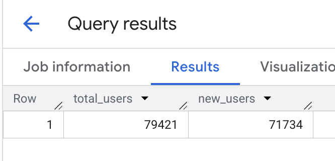

```sql
SELECT
  COUNT(*) AS total_users,
  SUM(is_new_user) AS new_users
FROM UserInfo;
```

### 1.0.1 **Explanation**

This query uses a Common Table Expression (CTE) to first identify whether each user is new. It checks if a user triggered either the first_visit or first_open event. The outer query then calculates total users and total new users. This helps measure user acquisition within the selected time period.

# 2 **Query 2 — Arrays + UNNEST**

## 2.1 **Part A — Scalar Subquery Extraction**

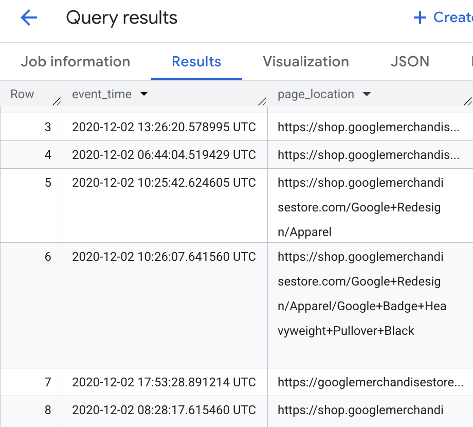

```sql
SELECT
  TIMESTAMP_MICROS(event_timestamp) AS event_time,
  (
    SELECT value.string_value
    FROM UNNEST(event_params)
    WHERE key = 'page_location'
    LIMIT 1
  ) AS page_location
FROM `bigquery-public-data.ga4_obfuscated_sample_ecommerce.events_*`
WHERE event_name = 'page_view'
  AND _TABLE_SUFFIX BETWEEN '20201201' AND '20201202'
LIMIT 50;
```

### 2.1.1 **Explanation**

This query extracts the page_location parameter from the event_params array using a scalar subquery. It does not change the row count because it does not flatten the array. This method is useful when you want to safely extract a single parameter value without altering the event-level grain.

## 2.2 **Part B — Flattening Items (Grain Change)**

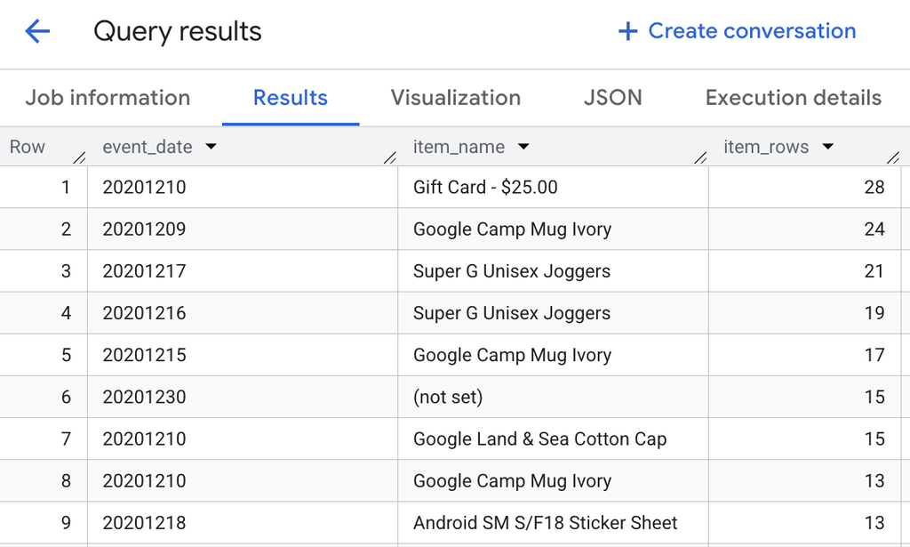

```sql
SELECT
  event_date,
  item.item_name,
  COUNT(*) AS item_rows
FROM `bigquery-public-data.ga4_obfuscated_sample_ecommerce.events_*` e,
UNNEST(e.items) AS item
WHERE e.event_name = 'purchase'
  AND _TABLE_SUFFIX BETWEEN '20201201' AND '20201231'
GROUP BY event_date, item.item_name
ORDER BY item_rows DESC
LIMIT 20;
```

### 2.2.1 **Explanation**

This query flattens the items array using UNNEST. Once it is unnnested, the grain changes from event-level to item-level, which allows analysis of individual products purchased rather than just counting purchase events.